# Insights Of The Ford GoBike System Data Exploration

## Dataset Overview

This data set includes information about individual rides made in a bike-sharing system covering the greater San Francisco Bay area. The data was obtained from the dataset options presented by Udacity in section 1.1. The dataset contains 183,412 records and 16 features:

start_time

end_time

start_station_id

start_station_name

start_station_latitude

start_station_longitude

end_station_id

end_station_name

end_station_latitude

end_station_longitude

bike_id

user_type

member_birth_year

member_gender

bike_share_for_all_trip.

## Visualization 1

## Univariate Exploration

This exploration has to do with investigating distributions of individual variables. The visualization below is showing the distribution of ages in the dataset. We can see from the distribution of the age of users that most users are between 20 to 45 years old.

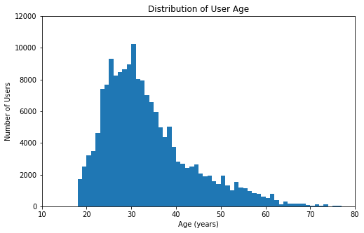

## Visualization 2

## Univariate Exploration

The visualization below is showing the start station id distribution in the dataset. We can see from the distribution that some stations in this dataset see more activity than others.

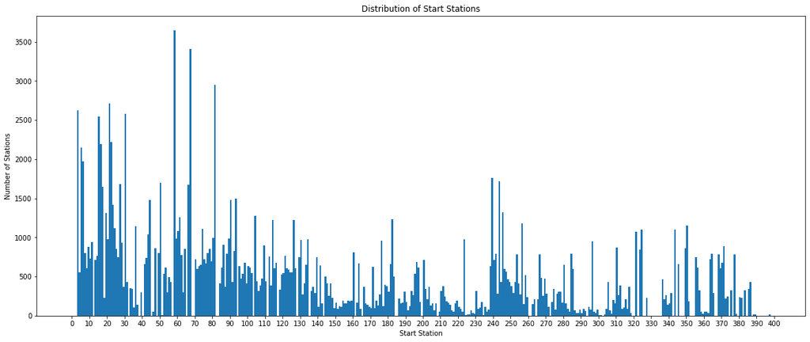

## Visualization 3

## Bivariate Exploration

This exploration has to do with investigating relationships between two pairs of variables in this dataset. The visualization below is showing the relationship between the various user type and the time duration. It is observed that higher percentage of customers are taking longer trips then compared to subscribers.

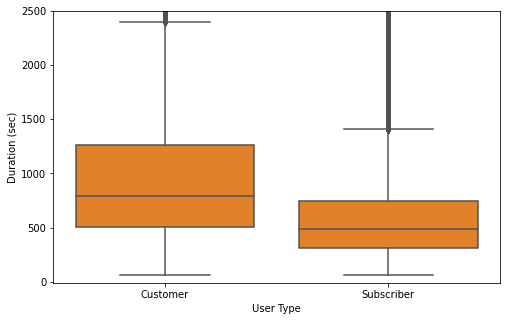